# Prediction Assignment Writeup

Hossam Saad

July 20,2020

## OverView

This document is the final report of the Peer Assessment project from Coursera’s course Practical Machine Learning, as part of the Specialization in Data Science. It was built in RStudio, using its knitr functions, meant to be published in html format. This analysis meant to be the basis for the course quiz and a prediction assignment writeup. The main goal of the project is to predict the manner in which 6 participants performed some exercise as described below. This is the “classe” variable in the training set. The machine learning algorithm described here is applied to the 20 test cases available in the test data and the predictions are submitted in appropriate format to the Course Project Prediction Quiz for automated grading.

## Loading Data

1- Data Source

[Training Set]https://d396qusza40orc.cloudfront.net/predmachlearn/pml-training.csv

The test data are available here:

[Test Set]https://d396qusza40orc.cloudfront.net/predmachlearn/pml-testing.csv

2- Loading Require packages

```r
library(knitr)
library(caret)
```

```r
library(rpart)
library(rpart.plot)
library(rattle)
library(randomForest)
library(corrplot)
library(gbm)
library(survival)
library(splines)
library(parallel)
library(pryr)
set.seed(199)
```

3- Cleaning Data

```r
TrainUrl <- "https://d396qusza40orc.cloudfront.net/predmachlearn/pml-training.csv"
TestUrl  <- "https://d396qusza40orc.cloudfront.net/predmachlearn/pml-testing.csv"
TrainFile<-"pml-traininig.csv"
TestFile<-"pml-testing.csv"

# download the datasets
if(!file.exists(TrainFile))
{
    download.file(TrainUrl,destfile = TrainFile)
}
trainingData <- read.csv(TrainFile)
if(!file.exists(TestFile))
{
    download.file(TestUrl,destfile = TestFile)
}
testingData  <- read.csv(TestFile)

# create a partition using caret with the training dataset on 70,30 ratio
inTrain  <- createDataPartition(trainingData$classe, p=0.7, list=FALSE)

TrainSet <- trainingData[inTrain, ]

TestSet  <- trainingData[-inTrain, ]
dim(TrainSet)
```

```
## [1] 13737   160
```

Clean Na , NZV

```r
NZV <- nearZeroVar(TrainSet)
TrainSet <- TrainSet[, -NZV]
TestSet  <- TestSet[, -NZV]
dim(TestSet)
```

```
## [1] 5885  105
```

```r
dim(TrainSet)
```

```
## [1] 13737   105
```

Remove Variables that have Na

```r
NaVar    <- sapply(TrainSet, function(x) mean(is.na(x))) > 0.95
TrainSet <- TrainSet[, NaVar==FALSE]
TestSet  <- TestSet[, NaVar==FALSE]
dim(TestSet)
```

```
## [1] 5885   59
```

```r
dim(TrainSet)
```

```
## [1] 13737    59
```

Remove the first 5 variables

```r
TrainSet <- TrainSet[, -(1:5)]
TestSet  <- TestSet[, -(1:5)]
dim(TrainSet)
```

```
## [1] 13737    54
```

4- Correction Analysis

let's see the corr b/w variables first.

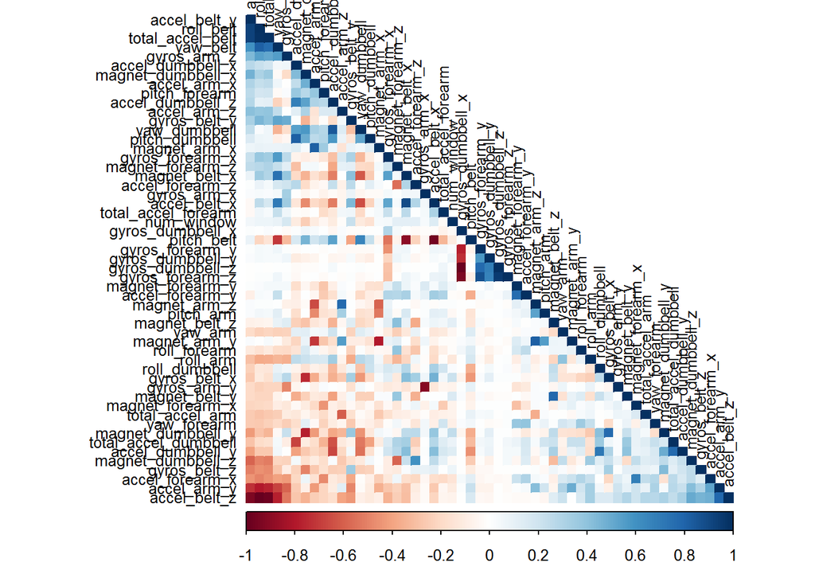

```r
corMatrix <- cor(TrainSet[, -54])
corrplot(corMatrix, order = "FPC", method = "color", type = "lower",
         tl.cex = 0.8, tl.col = rgb(0, 0, 0))
```

## Building Prediction model

Three popular methods will be applied to model the regressions (in the Train dataset) and the best one (with higher accuracy when applied to the Test dataset) will be used for the quiz predictions. The methods are: Random Forests, Decision Tree and Generalized Boosted Model, as described below. A Confusion Matrix is plotted at the end of each analysis to better visualize the accuracy of the models.

# 1- Random Forests

Fitting model

```r
set.seed(199)
RandomForestControl <- trainControl(method="cv", number=3, verboseIter=FALSE)
modFitRandForest <- train(classe ~ ., data=TrainSet, method="rf",
                          trControl=RandomForestControl)
modFitRandForest$finalModel
```

```
##
## Call:
##  randomForest(x = x, y = y, mtry = param$mtry)
##                Type of random forest: classification
##                      Number of trees: 500
## No. of variables tried at each split: 27
##
##         OOB estimate of  error rate: 0.28%
## Confusion matrix:
##      A    B    C    D    E  class.error
## A 3904    1    0    0    1 0.0005120328
## B    9 2646    2    1    0 0.0045146727
## C    0    9 2386    1    0 0.0041736227
## D    0    0    9 2242    1 0.0044404973
## E    0    1    0    4 2520 0.0019801980
```

Now let's doing a prediction on test dataset

```r
predictRandForest <- predict(modFitRandForest, newdata=TestSet)
confMatRandForest <- confusionMatrix(predictRandForest, TestSet$classe)
confMatRandForest
```

```
## Confusion Matrix and Statistics
##
##           Reference
## Prediction    A    B    C    D    E
##          A 1674    6    0    0    0
##          B    0 1132    2    0    0
##          C    0    1 1024    7    0
##          D    0    0    0  957    1
##          E    0    0    0    0 1081
##
## Overall Statistics
##
##                Accuracy : 0.9971
##                  95% CI : (0.9954, 0.9983)
##     No Information Rate : 0.2845
##     P-Value [Acc > NIR] : < 2.2e-16
##
##                   Kappa : 0.9963
##
##  Mcnemar's Test P-Value : NA
##
## Statistics by Class:
##
##                      Class: A Class: B Class: C Class: D Class: E
## Sensitivity            1.0000   0.9939   0.9981   0.9927   0.9991
## Specificity            0.9986   0.9996   0.9984   0.9998   1.0000
## Pos Pred Value         0.9964   0.9982   0.9922   0.9990   1.0000
## Neg Pred Value         1.0000   0.9985   0.9996   0.9986   0.9998
## Prevalence             0.2845   0.1935   0.1743   0.1638   0.1839
## Detection Rate         0.2845   0.1924   0.1740   0.1626   0.1837
## Detection Prevalence   0.2855   0.1927   0.1754   0.1628   0.1837
## Balanced Accuracy      0.9993   0.9967   0.9982   0.9963   0.9995
```

Ploting martix for Results

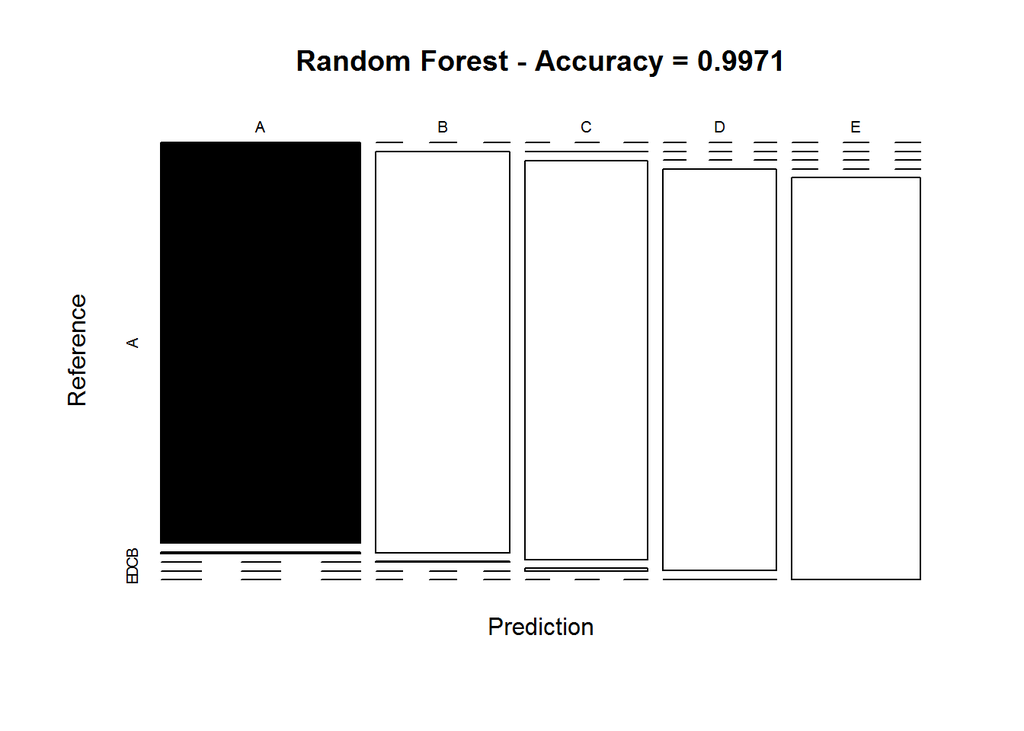

```r
plot(confMatRandForest$table, col = confMatRandForest$byClass,
     main = paste("Random Forest - Accuracy =",
                  round(confMatRandForest$overall['Accuracy'], 4)))
```

# 2- Decision Tree

Fitting model

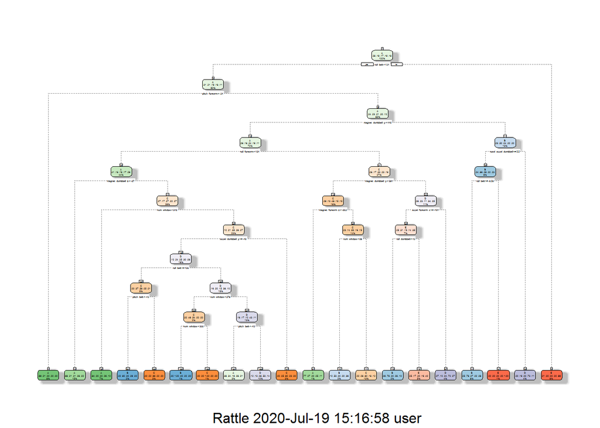

```r
set.seed(199)
modFitDecTree <- rpart(classe ~ ., data=TrainSet, method="class")
fancyRpartPlot(modFitDecTree)
```

Now let's doing a prediction on test dataset

```r
predictDecTree <- predict(modFitDecTree, newdata=TestSet, type="class")
confMatDecTree <- confusionMatrix(predictDecTree, TestSet$classe)
confMatDecTree
```

```
## Confusion Matrix and Statistics
##
##           Reference
## Prediction    A    B    C    D    E
##          A 1500  254   40  109   91
##          B   49  594   36   23   87
##          C   20   72  831  142   82
##          D   89  147   53  625  129
##          E   16   72   66   65  693
##
## Overall Statistics
##
##                Accuracy : 0.721
##                  95% CI : (0.7093, 0.7324)
##     No Information Rate : 0.2845
##     P-Value [Acc > NIR] : < 2.2e-16
##
##                   Kappa : 0.6451
##
##  Mcnemar's Test P-Value : < 2.2e-16
##
## Statistics by Class:
##
##                      Class: A Class: B Class: C Class: D Class: E
## Sensitivity            0.8961   0.5215   0.8099   0.6483   0.6405
## Specificity            0.8827   0.9589   0.9350   0.9151   0.9544
## Pos Pred Value         0.7523   0.7529   0.7245   0.5992   0.7599
## Neg Pred Value         0.9553   0.8931   0.9588   0.9300   0.9218
## Prevalence             0.2845   0.1935   0.1743   0.1638   0.1839
## Detection Rate         0.2549   0.1009   0.1412   0.1062   0.1178
## Detection Prevalence   0.3388   0.1341   0.1949   0.1772   0.1550
## Balanced Accuracy      0.8894   0.7402   0.8725   0.7817   0.7974
```

Ploting martix for Results

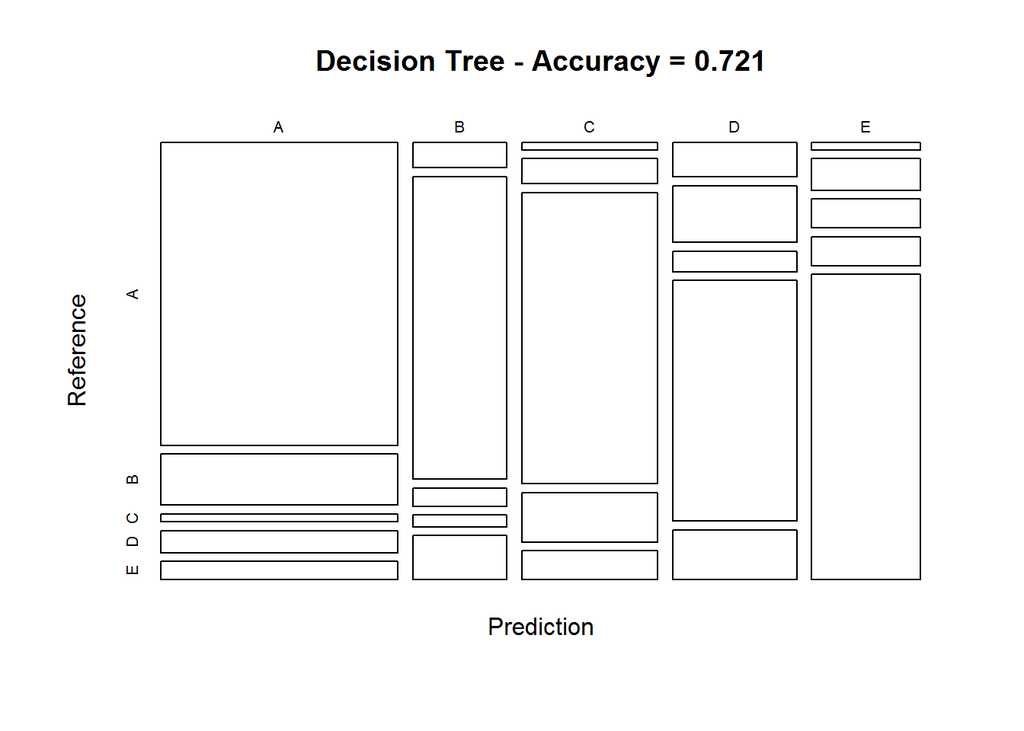

```r
plot(confMatDecTree$table, col = confMatDecTree$byClass,
     main = paste("Decision Tree - Accuracy =",
                  round(confMatDecTree$overall['Accuracy'], 4)))
```

# 3-Generalized Boosted Model

Fitting model

```r
set.seed(199)
controlGBM <- trainControl(method = "repeatedcv", number = 5, repeats = 1)
modFitGBM  <- train(classe ~ ., data=TrainSet, method = "gbm",
                    trControl = controlGBM, verbose = FALSE)
modFitGBM$finalModel
```

```
## A gradient boosted model with multinomial loss function.
## 150 iterations were performed.
## There were 53 predictors of which 53 had non-zero influence.
```

Now let's doing a prediction on test dataset

```r
predictGBM <- predict(modFitGBM, newdata=TestSet)
confMatGBM <- confusionMatrix(predictGBM, TestSet$classe)
confMatGBM
```

```
## Confusion Matrix and Statistics
##
##           Reference
## Prediction    A    B    C    D    E
##          A 1668    6    0    1    0
##          B    6 1126   14    8    4
##          C    0    6 1010   16    0
##          D    0    1    1  935    5
##          E    0    0    1    4 1073
##
## Overall Statistics
##
##                Accuracy : 0.9876
##                  95% CI : (0.9844, 0.9903)
##     No Information Rate : 0.2845
##     P-Value [Acc > NIR] : < 2.2e-16
##
##                   Kappa : 0.9843
##
##  Mcnemar's Test P-Value : NA
##
## Statistics by Class:
##
##                      Class: A Class: B Class: C Class: D Class: E
## Sensitivity            0.9964   0.9886   0.9844   0.9699   0.9917
## Specificity            0.9983   0.9933   0.9955   0.9986   0.9990
## Pos Pred Value         0.9958   0.9724   0.9787   0.9926   0.9954
## Neg Pred Value         0.9986   0.9972   0.9967   0.9941   0.9981
## Prevalence             0.2845   0.1935   0.1743   0.1638   0.1839
## Detection Rate         0.2834   0.1913   0.1716   0.1589   0.1823
## Detection Prevalence   0.2846   0.1968   0.1754   0.1601   0.1832
## Balanced Accuracy      0.9974   0.9909   0.9899   0.9842   0.9953
```

Plotting a matrix For Results

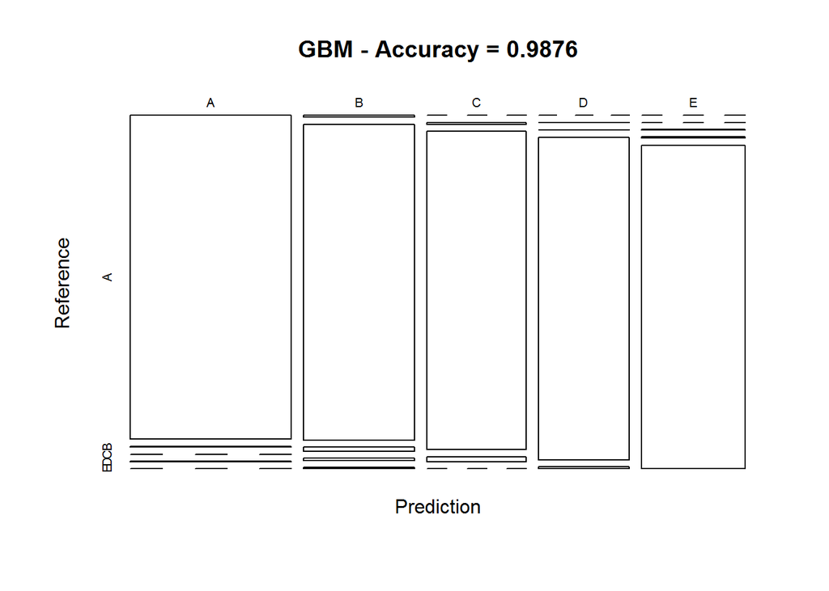

```r
plot(confMatGBM$table, col = confMatGBM$byClass,
     main = paste("GBM - Accuracy =", round(confMatGBM$overall['Accuracy'], 4)))
```

## Appling the Best Model to the Test Data

```r
predictTEST <- predict(modFitRandForest, newdata=testingData)
predictTEST
```

```
##  [1] B A B A A E D B A A B C B A E E A B B B
## Levels: A B C D E
```